# Skills Quiz: Regression Diagnostics

## Instructions

Use this file to keep a record of your work as you complete the “Skills Quiz: Regression Diagnostics” assignment in Canvas.

## Problem 1

Open the `Davis` dataset in R, found in `library(car)`. As stated in the help file for this data set, “The subjects were men and women engaged in regular exercise.”

Perform a simple linear regression of the height of the individual based on their weight.

### Part (a)

Type out the mathematical equation for this regression model and label both $Y$ and $X$ in the equation.

$$\underbrace{Y_i}_\text{height} = 160.0931 + 0.1509 \underbrace{X_i}_\text{weight} + \epsilon_i \quad \text{where} \ \epsilon_i \sim N(0, \sigma^2)$$

### Part (b)

Plot a scatterplot of the data with your regression line overlaid.

```r
library(car)
```

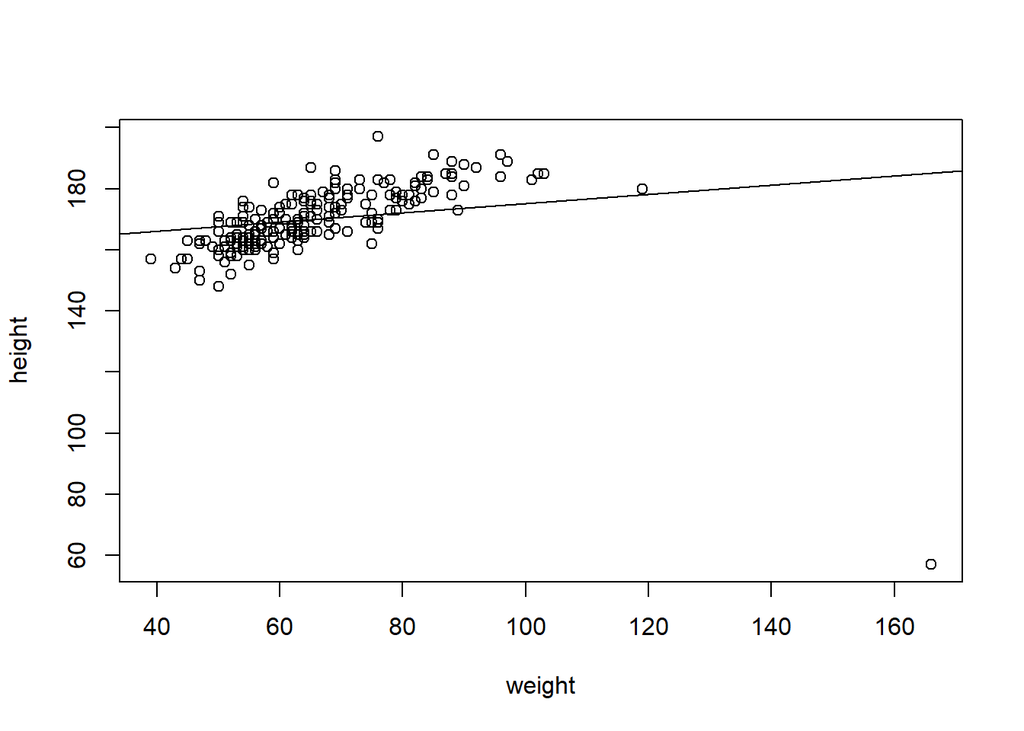

```r
davislm <- lm(height ~ weight, data = Davis)
plot(height ~ weight, data = Davis)
abline(davislm$coefficients[1], davislm$coefficients[2])
```

### Part (c)

Create a residuals vs fitted-values plot for this regression. What does this plot show?

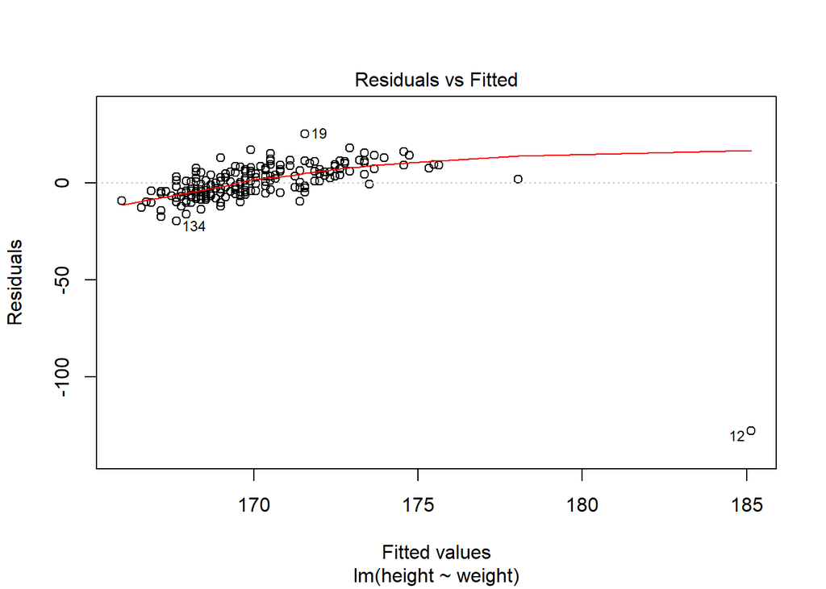

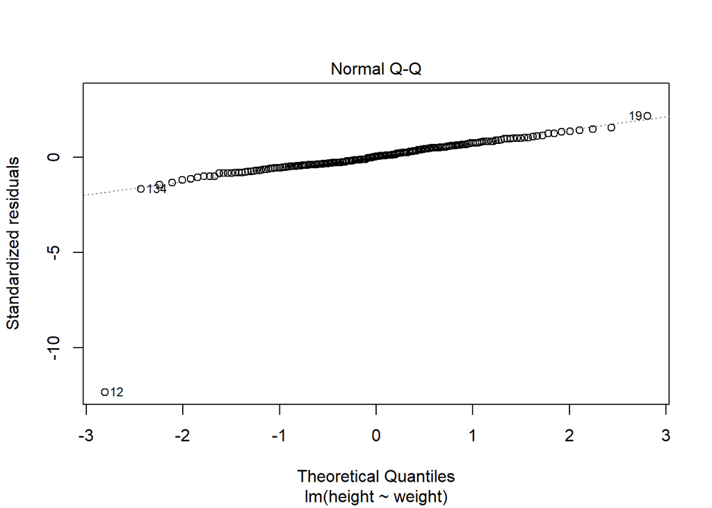

```r
plot(davislm, which = 1:2)
```

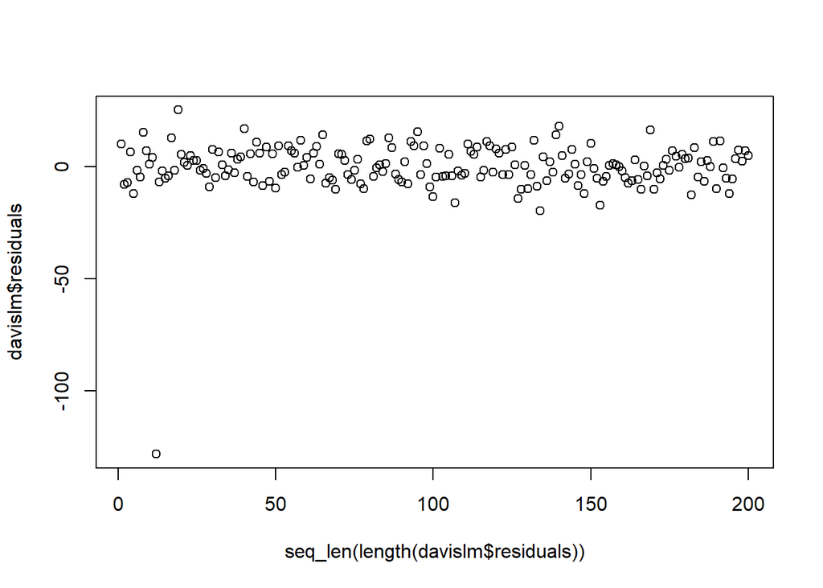

```r
plot(davislm$residuals ~ seq_len(length(davislm$residuals)))
```

Row 12 has the height and weight switched, which is messing up the model. Other than that it looks good, but I will be sure once I fix it.